# UPHL Reporting Limits: 2017

### 7.0 RLs from AWQMS data (2011 - Oct.2016)

`DATA ==` :: **AWQMS.Blank**

#### 7.1 **Total P**

```r
Blank.TPaq <- AWQMS.Blank[(AWQMS.Blank$Characteristic.Name == "Phosphate-phosphorus" & AWQMS.Blank$Sample.Fraction == "Total"),]
```

- Results for “Blank” MLIDs and Parameter = “Total P” includes 105 records
- Date Range: 2011-06-08 :: to :: 2016-09-28

*Correspondence b/w Detection Condition and Result Qualifiers for AWQMS data*

```r
addmargins(table(Blank.TPaq$Detection.Condition, Blank.TPaq$Result.Qualifier, useNA = "ifany", deparse.level = 2))
```

```
                              Blank.TPaq$Result.Qualifier
Blank.TPaq$Detection.Condition   J   U <NA> Sum
                  Not Detected   0  69    0  69
                  <NA>           5   0   31  36
                  Sum            5  69   31 105
```

**Detection Condition x Site.Type**

```r
tab4 <- as.data.frame.matrix(addmargins(table(Blank.TPaq$Site.Type, Blank.TPaq$Detection.Condition, useNA = "ifany")))
names(tab4)[c(1,2)] <- c("Not Detected", "< NA >")
tab4$Project <- rownames(tab4)
tab4 <- tab4[,c(ncol(tab4), 1:(ncol(tab4)-1))]
rownames(tab4) <- NULL
tab4$Percent_ND <- as.numeric(format(tab4$`Not Detected` / tab4$Sum, digits=2))*100
htmlTable::htmlTable(tab4, css.cell = rbind(rep("padding-left: 0.7em; padding-right: 0.9em;font-size: 0.8em;", times=ncol(tab4)), matrix("padding-left: 0.8em; padding-right: 0.8em; font-size: 0.8em;",ncol=ncol(tab4), nrow=nrow(tab4))), total=T, rnames=F, align="l|cc|c", caption="analyte Detections by Site Type, for Total P analyses")
```

| analyte Detections by Site Type, for Total P analyses Project | analyte Detections by Site Type, for Total P analyses Not Detected | analyte Detections by Site Type, for Total P analyses < NA > | analyte Detections by Site Type, for Total P analyses Sum | analyte Detections by Site Type, for Total P analyses Percent_ND |
| --- | --- | --- | --- | --- |
| Lake | 53 | 24 | 77 | 69 |
| River/Stream | 16 | 12 | 28 | 57 |
| Sum | 69 | 36 | 105 | 66 |

- In aggregate, 65.7% of “Total” dissolved phosphorus (DP) records were below analytical detection limits
  - Many projects define DQOs for “Blanks” to be below detection

**Result Flags x Site.Type**

```r
tab5 <- as.data.frame.matrix(addmargins(table(Blank.TPaq$Site.Type, Blank.TPaq$Result.Qualifier, useNA = "ifany")))
names(tab5)[c(1:3)] <- c("J", "U", "< NA >")
tab5$Project <- rownames(tab5)
tab5 <- tab5[,c(ncol(tab5), 1:(ncol(tab5)-1))]
rownames(tab5) <- NULL
tab5$Percent_ND <- as.numeric(format(tab5$`U` / tab5$Sum, digits=2))*100
htmlTable::htmlTable(tab5, css.cell = rbind(rep("padding-left: 0.7em; padding-right: 0.9em;font-size: 0.8em;", times=ncol(tab5)), matrix("padding-left: 0.8em; padding-right: 0.8em; font-size: 0.8em;",ncol=ncol(tab5), nrow=nrow(tab5))), total=T, rnames=F, align="l|ccc|c", caption="Problem Identifiers by Site Type, for Total P analyses")
```

| Problem Identifiers by Site Type, for Total P analyses Project | Problem Identifiers by Site Type, for Total P analyses J | Problem Identifiers by Site Type, for Total P analyses U | Problem Identifiers by Site Type, for Total P analyses < NA > | Problem Identifiers by Site Type, for Total P analyses Sum | Problem Identifiers by Site Type, for Total P analyses Percent_ND |
| --- | --- | --- | --- | --- | --- |
| Lake | 4 | 53 | 20 | 77 | 69 |
| River/Stream | 1 | 16 | 11 | 28 | 57 |
| Sum | 5 | 69 | 31 | 105 | 66 |

**Data Evaluation**

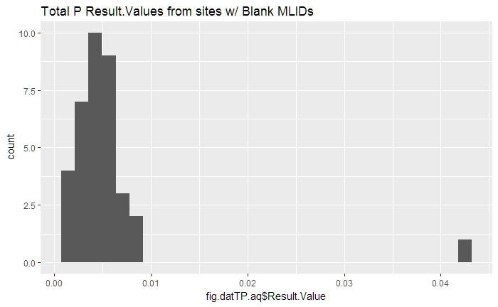

```r
library(ggplot2); library(scales)
fig.datTP.aq <- Blank.TPaq
# use Result.qualifier as "Flag"
fig.datTP.aq$Result.Value <- as.numeric(fig.datTP.aq$Result.Value)
#
qplot(fig.datTP.aq$Result.Value, main="Total P Result.Values from sites w/ Blank MLIDs ")
```

```r
summary(fig.datTP.aq$Result.Value[!is.na(fig.datTP.aq$Result.Qualifier) & fig.datTP.aq$Result.Qualifier == "J"])
```

```
   Min. 1st Qu.  Median    Mean 3rd Qu.    Max.
0.00090 0.00090 0.00110 0.00146 0.00190 0.00250
```

```r
summary(fig.datTP.aq$Result.Value[!is.na(fig.datTP.aq$Result.Qualifier) & fig.datTP.aq$Result.Qualifier == "U"])
```

```
   Min. 1st Qu.  Median    Mean 3rd Qu.    Max.    NA's
     NA      NA      NA     NaN      NA      NA      69
```

```r
summary(fig.datTP.aq$Result.Value[is.na(fig.datTP.aq$Result.Qualifier)])
```

```
   Min. 1st Qu.  Median    Mean 3rd Qu.    Max.
0.00300 0.00400 0.00458 0.00595 0.00550 0.04200
```

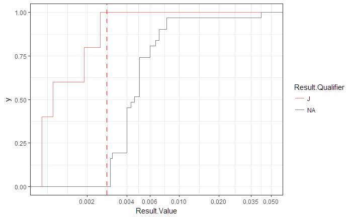

```r
ggplot(data=fig.datTP.aq) + theme_bw() +
        stat_ecdf(aes(x=Result.Value, color=Result.Qualifier), na.rm=T) +
        scale_x_continuous(trans="log10", oob=squish, limits=c(NA, 0.05),
                           breaks=c(0.002,0.004, 0.006, 0.01, 0.02, 0.035, 0.05)) +
    geom_vline(xintercept=0.0028, lty="99", color="red")
```

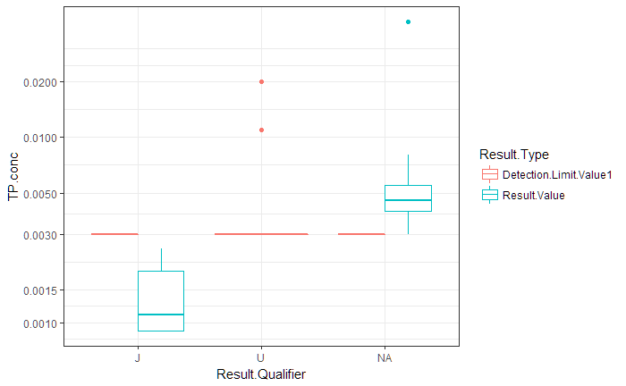

```r
#
library(tidyr);
fig.dat2 <- fig.datTP.aq[,c("Result.Value", "Detection.Limit.Value1", "Result.Qualifier")] %>%
    gather(key, value=TP.conc, -Result.Qualifier)
names(fig.dat2)[2] <- "Result.Type"
ggplot(data=fig.dat2) + theme_bw() + geom_boxplot(aes(x=Result.Qualifier, y=TP.conc, col=Result.Type), na.rm=T) +
    scale_y_continuous(limits=c(NA, NA), trans="log10", oob=squish, breaks=c(0.001, 0.0015, 0.003, 0.005, 0.01, 0.02))
```

```r
#
summary(fig.datTP.aq$Detection.Limit.Value1[!is.na(fig.datTP.aq$Result.Qualifier) & fig.datTP.aq$Result.Qualifier == "U"])
```

```
   Min. 1st Qu.  Median    Mean 3rd Qu.    Max.
0.00300 0.00300 0.00300 0.00526 0.00300 0.02000
```

```r
summary(fig.datTP.aq$Detection.Limit.Value1[!is.na(fig.datTP.aq$Result.Qualifier) & fig.datTP.aq$Result.Qualifier == "J"])
```

```
   Min. 1st Qu.  Median    Mean 3rd Qu.    Max.
  0.003   0.003   0.003   0.003   0.003   0.003
```

```r
length(unique(fig.datTP.aq$Detection.Limit.Value1))
```

```
[1] 4
```

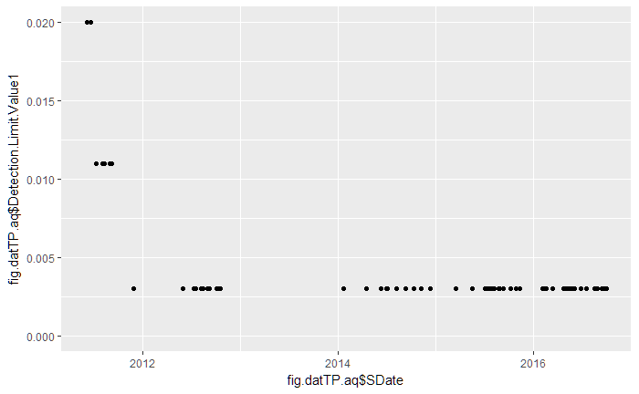

```r
qplot(fig.datTP.aq$SDate, fig.datTP.aq$Detection.Limit.Value1, ylim=c(0,NA))
```

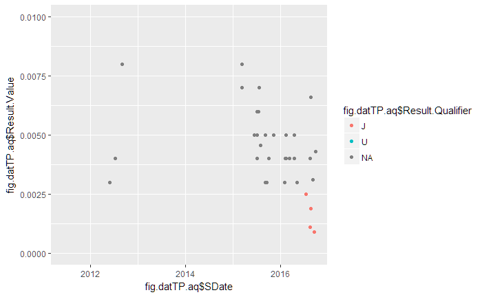

```r
qplot(fig.datTP.aq$SDate, fig.datTP.aq$Result.Value, col=fig.datTP.aq$Result.Qualifier, ylim=c(0, 0.01))
```

#### 7.2 **Dissolved P**

```r
Blank.DPaq <- AWQMS.Blank[(AWQMS.Blank$Characteristic.Name == "Phosphate-phosphorus" & AWQMS.Blank$Sample.Fraction == "Dissolved"),]
```

- Results for “Blank” MLIDs and Parameter = “Dissolved P” includes 663 records
- Date Range: 2011-06-08 :: to :: 2016-09-28

*Correspondence b/w Detection Condition and Result Qualifiers for AWQMS data*

```r
addmargins(table(Blank.DPaq$Detection.Condition, Blank.DPaq$Result.Qualifier, useNA = "ifany", deparse.level = 2))
```

```
                              Blank.DPaq$Result.Qualifier
Blank.DPaq$Detection.Condition   J   U <NA> Sum
                  Not Detected   0 290    0 290
                  <NA>          19   0  354 373
                  Sum           19 290  354 663
```

**Detection Condition x Site.Type**

```r
tab4X <- as.data.frame.matrix(addmargins(table(Blank.DPaq$Site.Type, Blank.DPaq$Detection.Condition, useNA = "ifany")))
names(tab4X)[c(1,2)] <- c("Not Detected", "< NA >")
tab4X$Project <- rownames(tab4X)
tab4X <- tab4X[,c(ncol(tab4X), 1:(ncol(tab4X)-1))]
rownames(tab4X) <- NULL
tab4X$Percent_ND <- as.numeric(format(tab4X$`Not Detected` / tab4X$Sum, digits=2))*100
htmlTable::htmlTable(tab4X, css.cell = rbind(rep("padding-left: 0.7em; padding-right: 0.9em;font-size: 0.8em;", times=ncol(tab4X)), matrix("padding-left: 0.8em; padding-right: 0.8em; font-size: 0.8em;",ncol=ncol(tab4X), nrow=nrow(tab4X))), total=T, rnames=F, align="l|cc|c", caption="Analyte Detections by Site Type, for Dissolved P analyses")
```

| Analyte Detections by Site Type, for Dissolved P analyses Project | Analyte Detections by Site Type, for Dissolved P analyses Not Detected | Analyte Detections by Site Type, for Dissolved P analyses < NA > | Analyte Detections by Site Type, for Dissolved P analyses Sum | Analyte Detections by Site Type, for Dissolved P analyses Percent_ND |
| --- | --- | --- | --- | --- |
| Lake | 64 | 49 | 113 | 57 |
| River/Stream | 226 | 324 | 550 | 41 |
| Sum | 290 | 373 | 663 | 44 |

- In aggregate, 43.7% of dissolved phosphorus (DP) records were below analytical detection limits
  - Many projects define DQOs for “Blanks” to be below detection

**Result Flags x Site.Type**

```r
tab5X <- as.data.frame.matrix(addmargins(table(Blank.DPaq$Site.Type, Blank.DPaq$Result.Qualifier, useNA = "ifany")))
names(tab5X)[c(1:3)] <- c("J", "U", "< NA >")
tab5X$Project <- rownames(tab5X)
tab5X <- tab5X[,c(ncol(tab5X), 1:(ncol(tab5X)-1))]
rownames(tab5X) <- NULL
tab5X$Percent_ND <- as.numeric(format(tab5X$`U` / tab5X$Sum, digits=2))*100
htmlTable::htmlTable(tab5X, css.cell = rbind(rep("padding-left: 0.7em; padding-right: 0.9em;font-size: 0.8em;", times=ncol(tab5X)), matrix("padding-left: 0.8em; padding-right: 0.8em; font-size: 0.8em;",ncol=ncol(tab5X), nrow=nrow(tab5X))), total=T, rnames=F, align="l|ccc|c", caption="Problem Identifiers by Site Type, for Dissolved P analyses")
```

| Problem Identifiers by Site Type, for Dissolved P analyses Project | Problem Identifiers by Site Type, for Dissolved P analyses J | Problem Identifiers by Site Type, for Dissolved P analyses U | Problem Identifiers by Site Type, for Dissolved P analyses < NA > | Problem Identifiers by Site Type, for Dissolved P analyses Sum | Problem Identifiers by Site Type, for Dissolved P analyses Percent_ND |
| --- | --- | --- | --- | --- | --- |
| Lake | 5 | 64 | 44 | 113 | 57 |
| River/Stream | 14 | 226 | 310 | 550 | 41 |
| Sum | 19 | 290 | 354 | 663 | 44 |

**Data Evaluation**

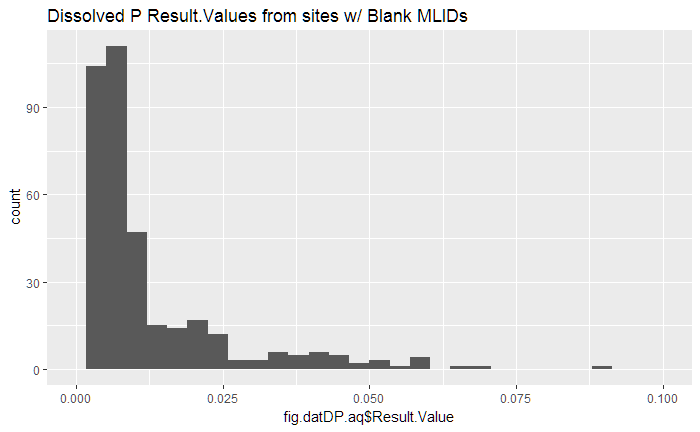

```r
library(ggplot2); library(scales)
fig.datDP.aq <- Blank.DPaq
# use Result.qualifier as "Flag"
fig.datDP.aq$Result.Value <- as.numeric(fig.datDP.aq$Result.Value)
#
qplot(fig.datDP.aq$Result.Value, main="Dissolved P Result.Values from sites w/ Blank MLIDs ", xlim=c(0, 0.1))
```

```r
summary(fig.datDP.aq$Result.Value[!is.na(fig.datDP.aq$Result.Qualifier) & fig.datDP.aq$Result.Qualifier == "J"])
```

```
   Min. 1st Qu.  Median    Mean 3rd Qu.    Max.
0.00140 0.00220 0.00260 0.00464 0.00850 0.01200
```

```r
summary(fig.datDP.aq$Result.Value[!is.na(fig.datDP.aq$Result.Qualifier) & fig.datDP.aq$Result.Qualifier == "U"])
```

```
   Min. 1st Qu.  Median    Mean 3rd Qu.    Max.    NA's
     NA      NA      NA     NaN      NA      NA     290
```

```r
summary(fig.datDP.aq$Result.Value[is.na(fig.datDP.aq$Result.Qualifier)])
```

```
   Min. 1st Qu.  Median    Mean 3rd Qu.    Max.
  0.001   0.005   0.008   0.439   0.017  30.200
```

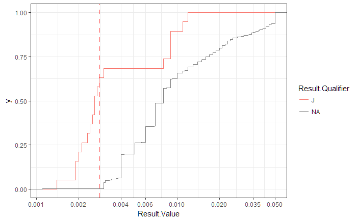

```r
ggplot(data=fig.datDP.aq) + theme_bw() +
        stat_ecdf(aes(x=Result.Value, color=Result.Qualifier), na.rm=T) +
        scale_x_continuous(trans="log10", oob=squish, limits=c(NA, 0.05),
                           breaks=c(0.001, 0.002,0.004, 0.006, 0.01, 0.02, 0.035, 0.05)) +
    geom_vline(xintercept=0.0028, lty="99", color="red")
```

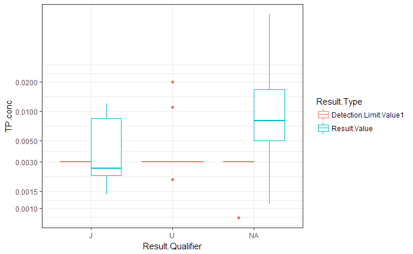

```r
#
library(tidyr);
fig.dat2X <- fig.datDP.aq[,c("Result.Value", "Detection.Limit.Value1", "Result.Qualifier")] %>%
    gather(key, value=TP.conc, -Result.Qualifier)
names(fig.dat2X)[2] <- "Result.Type"
ggplot(data=fig.dat2X) + theme_bw() + geom_boxplot(aes(x=Result.Qualifier, y=TP.conc, col=Result.Type), na.rm=T) +
    scale_y_continuous(limits=c(NA, 0.1), trans="log10", oob=squish, breaks=c(0.001, 0.0015, 0.003, 0.005, 0.01, 0.02))
```

```r
#
summary(fig.datDP.aq$Detection.Limit.Value1[!is.na(fig.datDP.aq$Result.Qualifier) & fig.datDP.aq$Result.Qualifier == "U"])
```

```
   Min. 1st Qu.  Median    Mean 3rd Qu.    Max.
0.00200 0.00300 0.00300 0.00407 0.00300 0.02000
```

```r
summary(fig.datDP.aq$Detection.Limit.Value1[!is.na(fig.datDP.aq$Result.Qualifier) & fig.datDP.aq$Result.Qualifier == "J"])
```

```
   Min. 1st Qu.  Median    Mean 3rd Qu.    Max.    NA's
  0.003   0.003   0.003   0.003   0.003   0.003       6
```

```r
length(unique(fig.datDP.aq$Detection.Limit.Value1))
```

```
[1] 6
```

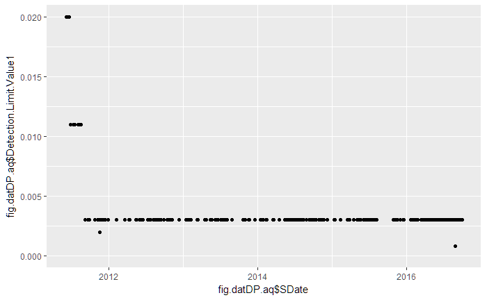

```r
qplot(fig.datDP.aq$SDate, fig.datDP.aq$Detection.Limit.Value1, ylim=c(0,NA))
```

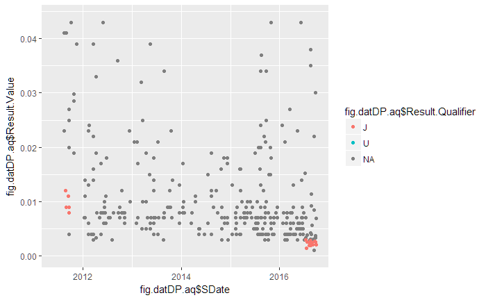

```r
qplot(fig.datDP.aq$SDate, fig.datDP.aq$Result.Value, col=fig.datDP.aq$Result.Qualifier, ylim=c(0, 0.044))
```

#### 7.3 **Dissolved NO3+NO2**

```r
Blank.dNO3aq <- AWQMS.Blank[(AWQMS.Blank$Characteristic.Name == "Inorganic nitrogen (nitrate and nitrite)" & AWQMS.Blank$Sample.Fraction == "Dissolved"),]
```

- Results for “Blank” MLIDs and Parameter = “Dissolved NO3” includes 506 records
- Date Range: 2011-06-08 :: to :: 2016-09-28

*Correspondence b/w Detection Condition and Result Qualifiers for AWQMS data*

```r
addmargins(table(Blank.dNO3aq$Detection.Condition, Blank.dNO3aq$Result.Qualifier, useNA = "ifany", deparse.level = 2))
```

```
                                Blank.dNO3aq$Result.Qualifier
Blank.dNO3aq$Detection.Condition   J   U <NA> Sum
                    Not Detected   0 188    1 189
                    <NA>         277   0   40 317
                    Sum          277 188   41 506
```

**Detection Condition x Site.Type**

```r
tab4Z <- as.data.frame.matrix(addmargins(table(Blank.dNO3aq$Site.Type, Blank.dNO3aq$Detection.Condition, useNA = "ifany")))
names(tab4Z)[c(1,2)] <- c("Not Detected", "< NA >")
tab4Z$Project <- rownames(tab4Z)
tab4Z <- tab4Z[,c(ncol(tab4Z), 1:(ncol(tab4Z)-1))]
rownames(tab4Z) <- NULL
tab4Z$Percent_ND <- as.numeric(format(tab4Z$`Not Detected` / tab4Z$Sum, digits=2))*100
htmlTable::htmlTable(tab4Z, css.cell = rbind(rep("padding-left: 0.7em; padding-right: 0.9em;font-size: 0.8em;", times=ncol(tab4Z)), matrix("padding-left: 0.8em; padding-right: 0.8em; font-size: 0.8em;",ncol=ncol(tab4Z), nrow=nrow(tab4Z))), total=T, rnames=F, align="l|cc|c", caption="analyte Detections by Site Type, for Dissolved NO3 analyses")
```

| analyte Detections by Site Type, for Dissolved NO3 analyses Project | analyte Detections by Site Type, for Dissolved NO3 analyses Not Detected | analyte Detections by Site Type, for Dissolved NO3 analyses < NA > | analyte Detections by Site Type, for Dissolved NO3 analyses Sum | analyte Detections by Site Type, for Dissolved NO3 analyses Percent_ND |
| --- | --- | --- | --- | --- |
| Lake | 71 | 43 | 114 | 62 |
| River/Stream | 118 | 274 | 392 | 30 |
| Sum | 189 | 317 | 506 | 37 |

- In aggregate, 37.4% of “Total” dissolved phosphorus (dNO3) records were below analytical detection limits
  - Many projects define DQOs for “Blanks” to be below detection

**Result Flags x Site.Type**

```r
tab5Z <- as.data.frame.matrix(addmargins(table(Blank.dNO3aq$Site.Type, Blank.dNO3aq$Result.Qualifier, useNA = "ifany")))
names(tab5Z)[c(1:3)] <- c("J", "U", "< NA >")
tab5Z$Project <- rownames(tab5Z)
tab5Z <- tab5Z[,c(ncol(tab5Z), 1:(ncol(tab5Z)-1))]
rownames(tab5Z) <- NULL
tab5Z$Percent_ND <- as.numeric(format(tab5Z$`U` / tab5Z$Sum, digits=2))*100
htmlTable::htmlTable(tab5Z, css.cell = rbind(rep("padding-left: 0.7em; padding-right: 0.9em;font-size: 0.8em;", times=ncol(tab5Z)), matrix("padding-left: 0.8em; padding-right: 0.8em; font-size: 0.8em;",ncol=ncol(tab5Z), nrow=nrow(tab5Z))), total=T, rnames=F, align="l|ccc|c", caption="Problem Identifiers by Site Type, for Dissolved NO3 analyses")
```

| Problem Identifiers by Site Type, for Dissolved NO3 analyses Project | Problem Identifiers by Site Type, for Dissolved NO3 analyses J | Problem Identifiers by Site Type, for Dissolved NO3 analyses U | Problem Identifiers by Site Type, for Dissolved NO3 analyses < NA > | Problem Identifiers by Site Type, for Dissolved NO3 analyses Sum | Problem Identifiers by Site Type, for Dissolved NO3 analyses Percent_ND |
| --- | --- | --- | --- | --- | --- |
| Lake | 43 | 71 | 0 | 114 | 62 |
| River/Stream | 234 | 117 | 41 | 392 | 30 |
| Sum | 277 | 188 | 41 | 506 | 37 |

**Data Evaluation**

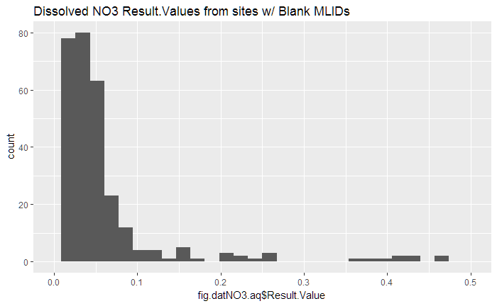

```r
library(ggplot2); library(scales)
fig.datNO3.aq <- Blank.dNO3aq
# use Result.qualifier as "Flag"
fig.datNO3.aq$Result.Value <- as.numeric(fig.datNO3.aq$Result.Value)
#
qplot(fig.datNO3.aq$Result.Value, main="Dissolved NO3 Result.Values from sites w/ Blank MLIDs ", xlim=c(0, 0.5))
```

```r
summary(fig.datNO3.aq$Result.Value[!is.na(fig.datNO3.aq$Result.Qualifier) & fig.datNO3.aq$Result.Qualifier == "J"])
```

```
   Min. 1st Qu.  Median    Mean 3rd Qu.    Max.
 0.0040  0.0179  0.0337  0.0358  0.0491  0.0960
```

```r
summary(fig.datNO3.aq$Result.Value[!is.na(fig.datNO3.aq$Result.Qualifier) & fig.datNO3.aq$Result.Qualifier == "U"])
```

```
   Min. 1st Qu.  Median    Mean 3rd Qu.    Max.    NA's
     NA      NA      NA     NaN      NA      NA     188
```

```r
summary(fig.datNO3.aq$Result.Value[is.na(fig.datNO3.aq$Result.Qualifier)])
```

```
   Min. 1st Qu.  Median    Mean 3rd Qu.    Max.    NA's
  0.101   0.159   0.246   0.435   0.440   2.440       1
```

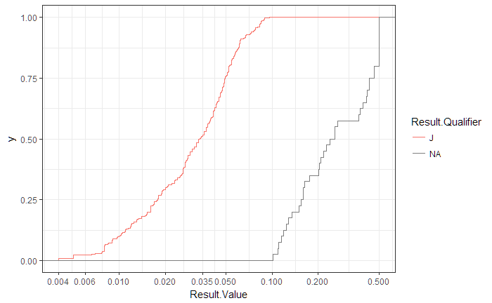

```r
ggplot(data=fig.datNO3.aq) + theme_bw() +
        stat_ecdf(aes(x=Result.Value, color=Result.Qualifier), na.rm=T) +
        scale_x_continuous(trans="log10", oob=squish, limits=c(NA, 0.5),
                           breaks=c(0.001, 0.002,0.004, 0.006, 0.01, 0.02, 0.035, 0.05, 0.1, 0.2, 0.5))
```

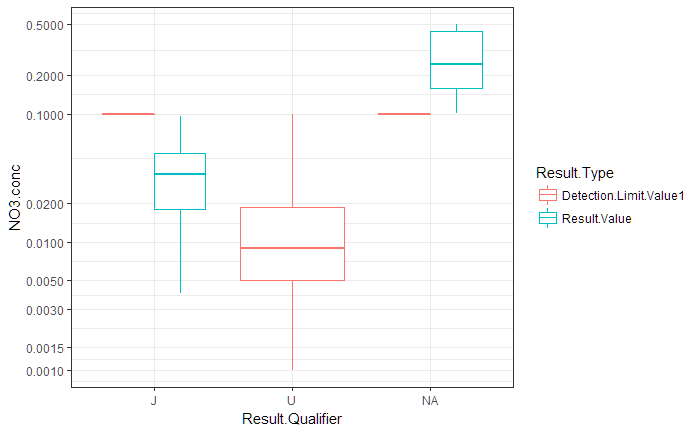

```r
#
library(tidyr);
fig.dat2Z <- fig.datNO3.aq[,c("Result.Value", "Detection.Limit.Value1", "Result.Qualifier")] %>%
    gather(key, value=NO3.conc, -Result.Qualifier)
names(fig.dat2Z)[2] <- "Result.Type"
ggplot(data=fig.dat2Z) + theme_bw() + geom_boxplot(aes(x=Result.Qualifier, y=NO3.conc, col=Result.Type), na.rm=T) +
    scale_y_continuous(limits=c(NA, 0.5), trans="log10", oob=squish, breaks=c(0.001, 0.0015, 0.003, 0.005, 0.01, 0.02, 0.1, 0.2, 0.5))
```

```r
#
summary(fig.datNO3.aq$Detection.Limit.Value1[!is.na(fig.datNO3.aq$Result.Qualifier) & fig.datNO3.aq$Result.Qualifier == "U"])
```

```
   Min. 1st Qu.  Median    Mean 3rd Qu.    Max.
 0.0010  0.0050  0.0090  0.0278  0.0200  0.1000
```

```r
summary(fig.datNO3.aq$Detection.Limit.Value1[!is.na(fig.datNO3.aq$Result.Qualifier) & fig.datNO3.aq$Result.Qualifier == "J"])
```

```
   Min. 1st Qu.  Median    Mean 3rd Qu.    Max.    NA's
    0.1     0.1     0.1     0.1     0.1     0.1     263
```

```r
length(unique(fig.datNO3.aq$Detection.Limit.Value1))
```

```
[1] 9
```

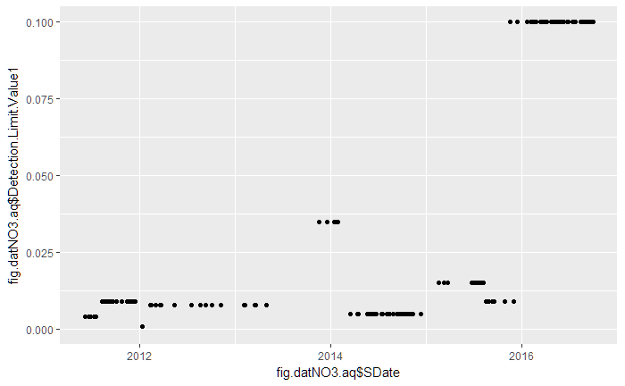

```r
qplot(fig.datNO3.aq$SDate, fig.datNO3.aq$Detection.Limit.Value1, ylim=c(0,NA))
```

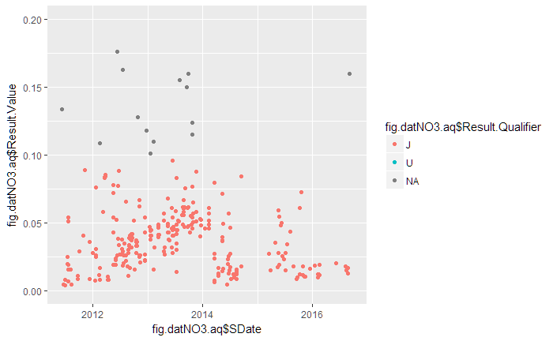

```r
qplot(fig.datNO3.aq$SDate, fig.datNO3.aq$Result.Value, col=fig.datNO3.aq$Result.Qualifier, ylim=c(0, 0.2))
```

### 8.0 Combined Blank Data

#### 8.1 **Total P**

**Combine Data for TP**

```r
Blank_TPcombo <- Blank.TP[,c("Sample.Date", "Matrix.Description", "Result.Code", "Result.Value",
                             "Lower.Report.Limit", "Method.Detect.Limit", "Analysis.Date",
                             "ParamX")]
Blank_tp2 <- Blank.TPaq[,c("SDate", "Sample.Fraction", "Result.Qualifier", "Result.Value",
                           "Detection.Limit.Value1", "Analysis.Start.Date")]
Blank_tp2$Method.Detect.Limit <- NA
Blank_tp2$ParamX <- "TP"
Blank_tp2 <- Blank_tp2[,c(1,2,3,4,5,7,6,8)]
names(Blank_TPcombo) <- c("SDate", "Fraction", "RCode", "Result.Value", "LRL", "MDL", "ADate", "ParamX")
names(Blank_tp2) <- c("SDate", "Fraction", "RCode", "Result.Value", "LRL", "MDL", "ADate", "ParamX")
Blank.TP.all <- rbind(Blank_TPcombo, Blank_tp2)
# fix empty.vals
Blank.TP.all$RCode[Blank.TP.all$RCode == ""] <- NA
Blank.TP.all$Result.Value <- as.numeric(Blank.TP.all$Result.Value)
```

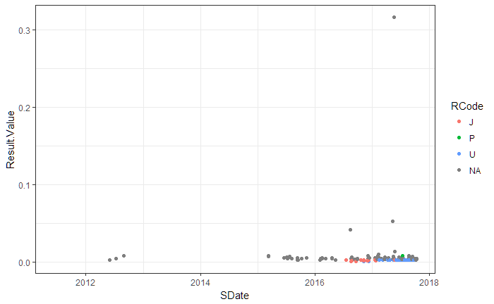

```r
ggplot(data=Blank.TP.all, aes(x=SDate, y=Result.Value), na.rm=T) + theme_bw() +
    geom_point(aes(col=RCode), na.rm=T)
```

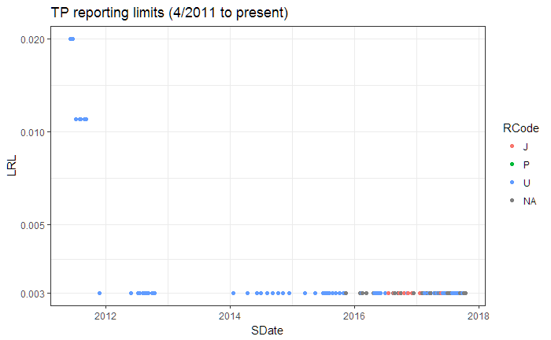

```r
ggplot(data=Blank.TP.all, aes(x=SDate, y=LRL), na.rm=T) + theme_bw() +
    geom_point(aes(col=RCode), na.rm=T) + scale_y_continuous(limits=c(NA, 0.02), trans="log10", oob=squish, breaks=c(0.001, 0.0015, 0.003, 0.005, 0.01, 0.02)) +
    ggtitle("TP reporting limits (4/2011 to present)")
```

#### 8.2 **Dissolved P**

**Combine Data for DP**

```r
Blank_DPcombo <- Blank.DP[,c("Sample.Date", "Matrix.Description", "Result.Code", "Result.Value",
                             "Lower.Report.Limit", "Method.Detect.Limit", "Analysis.Date",
                             "ParamX")]
Blank_DP2 <- Blank.DPaq[,c("SDate", "Sample.Fraction", "Result.Qualifier", "Result.Value",
                           "Detection.Limit.Value1", "Analysis.Start.Date")]
Blank_DP2$Method.Detect.Limit <- NA
Blank_DP2$ParamX <- "DP"
Blank_DP2 <- Blank_DP2[,c(1,2,3,4,5,7,6,8)]
names(Blank_DPcombo) <- c("SDate", "Fraction", "RCode", "Result.Value", "LRL", "MDL", "ADate", "ParamX")
names(Blank_DP2) <- c("SDate", "Fraction", "RCode", "Result.Value", "LRL", "MDL", "ADate", "ParamX")
Blank.DP.all <- rbind(Blank_DPcombo, Blank_DP2)
Blank.DP.all$ParamX <- "DP"
Blank.DP.all$RCode[Blank.DP.all$RCode == ""] <- NA
Blank.DP.all$Result.Value <- as.numeric(Blank.DP.all$Result.Value)
```

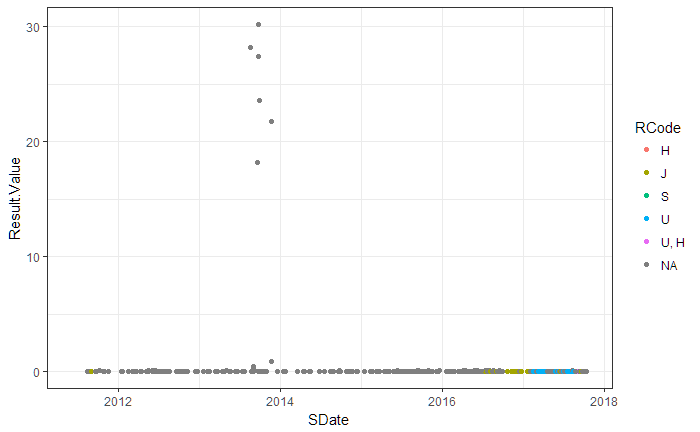

```r
ggplot(data=Blank.DP.all, aes(x=SDate, y=Result.Value), na.rm=T) + theme_bw() +
    geom_point(aes(col=RCode), na.rm=T)
```

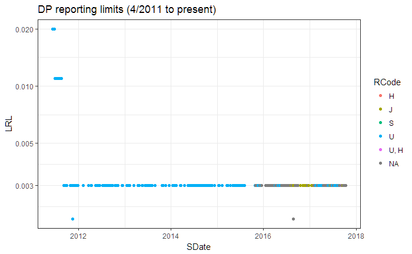

```r
ggplot(data=Blank.DP.all, aes(x=SDate, y=LRL), na.rm=T) + theme_bw() +
    geom_point(aes(col=RCode), na.rm=T) + scale_y_continuous(limits=c(0.002, 0.02), trans="log10", oob=squish, breaks=c(0.0015, 0.003, 0.005, 0.01, 0.02)) +
    ggtitle("DP reporting limits (4/2011 to present)")
```

#### 8.3 **Dissolved NO3**

**Combine Data for dNO3**

```r
Blank_dNO3combo <- Blank.dNO3[,c("Sample.Date", "Matrix.Description", "Result.Code", "Result.Value",
                             "Lower.Report.Limit", "Method.Detect.Limit", "Analysis.Date",
                             "ParamX")]
Blank_dNO32 <- Blank.dNO3aq[,c("SDate", "Sample.Fraction", "Result.Qualifier", "Result.Value",
                           "Detection.Limit.Value1", "Analysis.Start.Date")]
Blank_dNO32$Method.Detect.Limit <- NA
Blank_dNO32$ParamX <- "dNO3"
Blank_dNO32 <- Blank_dNO32[,c(1,2,3,4,5,7,6,8)]
names(Blank_dNO3combo) <- c("SDate", "Fraction", "RCode", "Result.Value", "LRL", "MDL", "ADate", "ParamX")
names(Blank_dNO32) <- c("SDate", "Fraction", "RCode", "Result.Value", "LRL", "MDL", "ADate", "ParamX")
Blank.dNO3.all <- rbind(Blank_dNO3combo, Blank_dNO32)
Blank.dNO3.all$ParamX <- "dNO3"
Blank.dNO3.all$RCode[Blank.dNO3.all$RCode == ""] <- NA
Blank.dNO3.all$Result.Value <- as.numeric(Blank.dNO3.all$Result.Value)
```

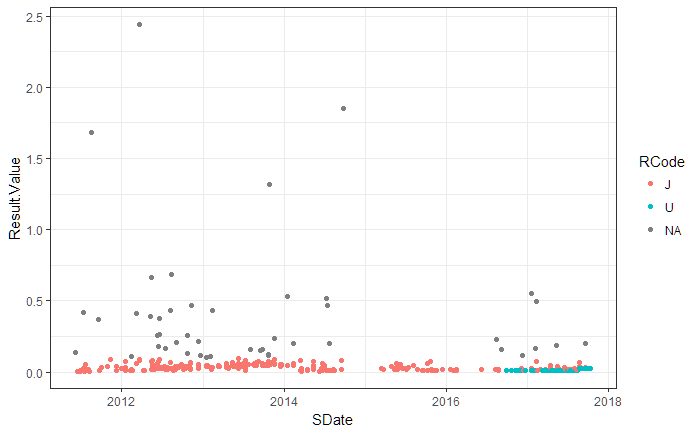

```r
ggplot(data=Blank.dNO3.all, aes(x=SDate, y=Result.Value), na.rm=T) + theme_bw() +
    geom_point(aes(col=RCode), na.rm=T)
```

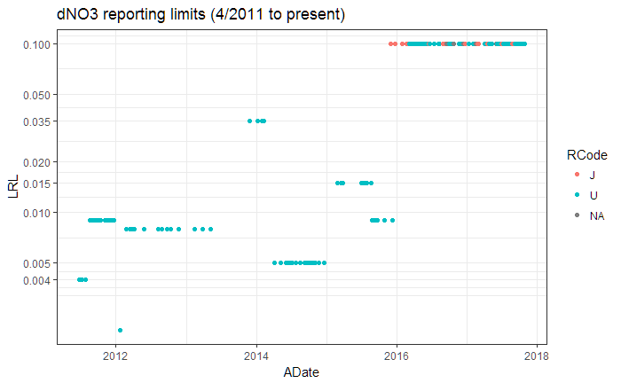

```r
ggplot(data=Blank.dNO3.all, aes(x=ADate, y=LRL), na.rm=T) + theme_bw() +
    geom_point(aes(col=RCode), na.rm=T) + scale_y_continuous(limits=c(0.002, NA), trans="log10", oob=squish, breaks=c(0.004, 0.005, 0.01, 0.015, 0.02, 0.035, 0.05, 0.1, 0.2)) +
    ggtitle("dNO3 reporting limits (4/2011 to present)")
```

### Summary

```r
Blank.TP.all <- dplyr::arrange(Blank.TP.all, ADate)
TP.tab1 <- dplyr::distinct(Blank.TP.all[!is.na(Blank.TP.all$LRL),], LRL, .keep_all = TRUE)
for (j in TP.tab1$LRL) {
    TP.tab1$n_Obs[TP.tab1$LRL == j] <- nrow(Blank.TP.all[!is.na(Blank.TP.all$LRL) & Blank.TP.all$LRL == j,])    }
#
Blank.DP.all <- dplyr::arrange(Blank.DP.all, ADate)
DP.tab1 <- dplyr::distinct(Blank.DP.all[!is.na(Blank.DP.all$LRL),], LRL, .keep_all = TRUE)
for (j in DP.tab1$LRL) {
    DP.tab1$n_Obs[DP.tab1$LRL == j] <- nrow(Blank.DP.all[!is.na(Blank.DP.all$LRL) & Blank.DP.all$LRL == j,])    }
#
Blank.dNO3.all <- dplyr::arrange(Blank.dNO3.all, ADate)
dNO3.tab1 <- dplyr::distinct(Blank.dNO3.all[!is.na(Blank.dNO3.all$LRL),], LRL, .keep_all = TRUE)
for (j in dNO3.tab1$LRL) {
    dNO3.tab1$n_Obs[dNO3.tab1$LRL == j] <- nrow(Blank.dNO3.all[!is.na(Blank.dNO3.all$LRL) & Blank.dNO3.all$LRL == j,])    }
```

```r
t1 <- TP.tab1[,c(-1,-4,-6)]
htmlTable::htmlTable(t1, css.cell = rbind(rep("padding-left: 0.7em; padding-right: 0.9em;font-size: 0.8em;", times=ncol(t1)), matrix("padding-left: 0.8em; padding-right: 0.8em; font-size: 0.8em;",ncol=ncol(t1), nrow=nrow(t1))), rnames=F, align="l|ccc|c", caption="Changes in LRL over time :: Total P")
```

| Changes in LRL over time :: Total P Fraction | Changes in LRL over time :: Total P RCode | Changes in LRL over time :: Total P LRL | Changes in LRL over time :: Total P ADate | Changes in LRL over time :: Total P ParamX | Changes in LRL over time :: Total P n_Obs |
| --- | --- | --- | --- | --- | --- |
| Total | U | 0.02 | 2011-06-24 | TP | 4 |
| Total | U | 0.011 | 2011-08-03 | TP | 11 |
| Total | U | 0.003 | 2011-12-09 | TP | 230 |

```r
t1 <- DP.tab1[,c(-1,-4,-6)]
htmlTable::htmlTable(t1, css.cell = rbind(rep("padding-left: 0.7em; padding-right: 0.9em;font-size: 0.8em;", times=ncol(t1)), matrix("padding-left: 0.8em; padding-right: 0.8em; font-size: 0.8em;",ncol=ncol(t1), nrow=nrow(t1))), rnames=F, align="l|ccc|c", caption="Changes in LRL over time :: Dissolved P")
```

| Changes in LRL over time :: Dissolved P Fraction | Changes in LRL over time :: Dissolved P RCode | Changes in LRL over time :: Dissolved P LRL | Changes in LRL over time :: Dissolved P ADate | Changes in LRL over time :: Dissolved P ParamX | Changes in LRL over time :: Dissolved P n_Obs |
| --- | --- | --- | --- | --- | --- |
| Dissolved | U | 0.02 | 2011-06-23 | DP | 7 |
| Dissolved | U | 0.011 | 2011-07-21 | DP | 24 |
| Dissolved | U | 0.003 | 2011-09-28 | DP | 560 |
| Dissolved | U | 0.002 | 2011-12-09 | DP | 1 |
| Dissolved |  | 0.000802 | 2016-09-27 | DP | 1 |

```r
t1 <- dNO3.tab1[,c(-1,-4,-6)]
htmlTable::htmlTable(t1, css.cell = rbind(rep("padding-left: 0.7em; padding-right: 0.9em;font-size: 0.8em;", times=ncol(t1)), matrix("padding-left: 0.8em; padding-right: 0.8em; font-size: 0.8em;",ncol=ncol(t1), nrow=nrow(t1))), rnames=F, align="l|ccc|c", caption="Changes in LRL over time :: Dissolved NO3+NO2")
```

| Changes in LRL over time :: Dissolved NO3+NO2 Fraction | Changes in LRL over time :: Dissolved NO3+NO2 RCode | Changes in LRL over time :: Dissolved NO3+NO2 LRL | Changes in LRL over time :: Dissolved NO3+NO2 ADate | Changes in LRL over time :: Dissolved NO3+NO2 ParamX | Changes in LRL over time :: Dissolved NO3+NO2 n_Obs |
| --- | --- | --- | --- | --- | --- |
| Dissolved | U | 0.004 | 2011-06-23 | dNO3 | 8 |
| Dissolved | U | 0.009 | 2011-08-18 | dNO3 | 51 |
| Dissolved | U | 0.001 | 2012-01-23 | dNO3 | 1 |
| Dissolved | U | 0.008 | 2012-02-23 | dNO3 | 19 |
| Dissolved | U | 0.035 | 2013-11-26 | dNO3 | 10 |
| Dissolved | U | 0.005 | 2014-04-03 | dNO3 | 40 |
| Dissolved | U | 0.015 | 2015-02-26 | dNO3 | 22 |
| Dissolved | J | 0.1 | 2015-12-01 | dNO3 | 238 |

```r
tab <- as.data.frame.matrix(addmargins(table(as.numeric(format(Blank.dNO3.all$SDate, "%Y")), Blank.dNO3.all$RCode, useNA = "ifany", deparse.level = 2)))
names(tab)[c(3)] <- c("< NA >")
tab$Year <- rownames(tab)
tab <- tab[,c(ncol(tab), 1:(ncol(tab)-1))]
rownames(tab) <- NULL
tab$Percent_ND <- as.numeric(format(tab$U / tab$Sum, digits=2))*100
htmlTable::htmlTable(tab, css.cell = rbind(rep("padding-left: 0.7em; padding-right: 0.9em;font-size: 0.8em;", times=ncol(tab)), matrix("padding-left: 0.8em; padding-right: 0.8em; font-size: 0.8em;",ncol=ncol(tab), nrow=nrow(tab))), total=T, rnames=F, align="l|cc|c", caption="analyte Detections by Site Type, for dNO3")
```

| analyte Detections by Site Type, for dNO3 Year | analyte Detections by Site Type, for dNO3 J | analyte Detections by Site Type, for dNO3 U | analyte Detections by Site Type, for dNO3 < NA > | analyte Detections by Site Type, for dNO3 Sum | analyte Detections by Site Type, for dNO3 Percent_ND |
| --- | --- | --- | --- | --- | --- |
| 2011 | 23 | 47 | 4 | 74 | 63.5 |
| 2012 | 86 | 14 | 18 | 118 | 11.9 |
| 2013 | 85 | 8 | 10 | 103 | 7.8 |
| 2014 | 44 | 48 | 6 | 98 | 49 |
| 2015 | 27 | 34 | 0 | 61 | 55.7 |
| 2016 | 16 | 54 | 4 | 74 | 73 |
| 2017 | 36 | 121 | 5 | 162 | 74.7 |
| Sum | 317 | 326 | 47 | 690 | 47.2 |

```r
tab <- as.data.frame.matrix(addmargins(table(as.numeric(format(Blank.TP.all$SDate, "%Y")), Blank.TP.all$RCode, useNA = "ifany", deparse.level = 2)))
names(tab)[c(4)] <- c("< NA >")
tab$Year <- rownames(tab)
tab <- tab[,c(ncol(tab), 1:(ncol(tab)-1))]
rownames(tab) <- NULL
tab$Percent_ND <- as.numeric(format(tab$U / tab$Sum, digits=2))*100
htmlTable::htmlTable(tab, css.cell = rbind(rep("padding-left: 0.7em; padding-right: 0.9em;font-size: 0.8em;", times=ncol(tab)), matrix("padding-left: 0.8em; padding-right: 0.8em; font-size: 0.8em;",ncol=ncol(tab), nrow=nrow(tab))), total=T, rnames=F, align="l|cc|c", caption="analyte Detections by Site Type, for TP")
```

| analyte Detections by Site Type, for TP Year | analyte Detections by Site Type, for TP J | analyte Detections by Site Type, for TP P | analyte Detections by Site Type, for TP U | analyte Detections by Site Type, for TP < NA > | analyte Detections by Site Type, for TP Sum | analyte Detections by Site Type, for TP Percent_ND |
| --- | --- | --- | --- | --- | --- | --- |
| 2011 | 0 | 0 | 16 | 0 | 16 | 100 |
| 2012 | 0 | 0 | 16 | 3 | 19 | 84 |
| 2014 | 0 | 0 | 10 | 0 | 10 | 100 |
| 2015 | 0 | 0 | 17 | 15 | 32 | 53 |
| 2016 | 15 | 0 | 12 | 18 | 45 | 27 |
| 2017 | 12 | 1 | 55 | 72 | 140 | 39 |
| Sum | 27 | 1 | 126 | 108 | 262 | 48 |

```r
tab <- as.data.frame.matrix(addmargins(table(as.numeric(format(Blank.DP.all$SDate, "%Y")), Blank.DP.all$RCode, useNA = "ifany", deparse.level = 2)))
names(tab)[c(6)] <- c("< NA >")
tab$Year <- rownames(tab)
tab <- tab[,c(ncol(tab), 1:(ncol(tab)-1))]
rownames(tab) <- NULL
tab$Percent_ND <- as.numeric(format(tab$U / tab$Sum, digits=2))*100
htmlTable::htmlTable(tab, css.cell = rbind(rep("padding-left: 0.7em; padding-right: 0.9em;font-size: 0.8em;", times=ncol(tab)), matrix("padding-left: 0.8em; padding-right: 0.8em; font-size: 0.8em;",ncol=ncol(tab), nrow=nrow(tab))), total=T, rnames=F, align="l|cc|c", caption="analyte Detections by Site Type, for DP")
```

| analyte Detections by Site Type, for DP Year | analyte Detections by Site Type, for DP H | analyte Detections by Site Type, for DP J | analyte Detections by Site Type, for DP S | analyte Detections by Site Type, for DP U | analyte Detections by Site Type, for DP U, H | analyte Detections by Site Type, for DP < NA > | analyte Detections by Site Type, for DP Sum | analyte Detections by Site Type, for DP Percent_ND |
| --- | --- | --- | --- | --- | --- | --- | --- | --- |
| 2011 | 0 | 6 | 0 | 54 | 0 | 13 | 73 | 74 |
| 2012 | 0 | 0 | 0 | 55 | 0 | 59 | 114 | 48 |
| 2013 | 0 | 0 | 0 | 46 | 0 | 58 | 104 | 44 |
| 2014 | 0 | 0 | 0 | 78 | 0 | 40 | 118 | 66 |
| 2015 | 0 | 0 | 0 | 41 | 0 | 99 | 140 | 29 |
| 2016 | 0 | 30 | 0 | 16 | 0 | 91 | 137 | 12 |
| 2017 | 3 | 15 | 1 | 65 | 4 | 81 | 169 | 38 |
| Sum | 3 | 51 | 1 | 355 | 4 | 441 | 855 | 42 |

### Wrap-Up

**Project Complete (171212); emailed to R. Weissiner at NPS**

**Start work date ::** 171204  
**Last work date ::** 171212  
**Current work / review date ::** 171212

eof